# City Graphs

Dina Sinclair

July 17, 2018

```r
source("C:/Users/Dina/Documents/Oxford/Evaluating Prior Impact/cities_main_code.R")
```

```
## rstan (Version 2.17.3, GitRev: 2e1f913d3ca3)
```

```
## For execution on a local, multicore CPU with excess RAM we recommend calling
## options(mc.cores = parallel::detectCores()).
## To avoid recompilation of unchanged Stan programs, we recommend calling
## rstan_options(auto_write = TRUE)
```

```r
library(reshape2)
library(ggplot2)
set.seed(17)
```

```r
N <- 16
pilot_c1 <- numeric(N)
pilot_c2 <- numeric(N)
sample <- seq(0,1.5,length.out = N)

for (i in 1:N){
  data <- list(I=2,Y=c(sample[i],0),sigmaSq=c(1,1))
  results <- overall(data=data,num_pilots=1,num_final_cities=1,num_draws=100)
  pilot_c1[i] <- results$nmc[1]
  pilot_c2[i] <- results$nmc[2]
  print(i)
  print(sample[i])

}

df <- data.frame(sample, pilot_c1, pilot_c2)
save(df, file="testing_mean.Rda")
```

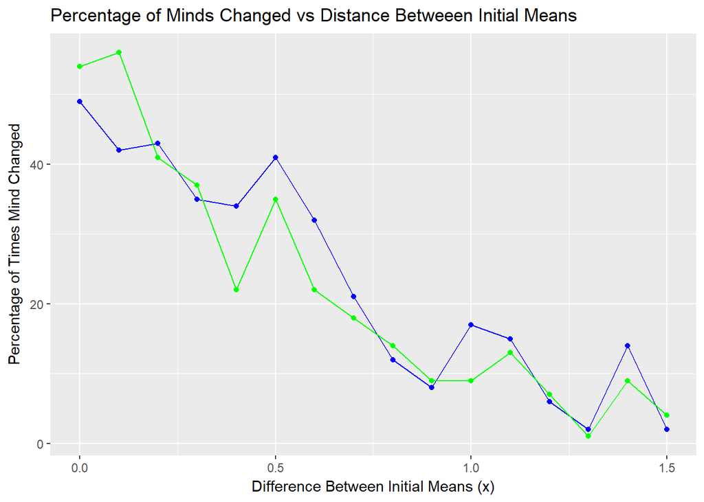

```r
load("testing_mean.Rda")
ggplot(df, aes(sample)) +
  geom_line(aes(y=pilot_c1), colour="blue") + geom_point(aes(y=pilot_c1), colour="blue")  +
  geom_line(aes(y=pilot_c2), colour="green") + geom_point(aes(y=pilot_c2), colour="green")  +
  ylab("Percentage of Times Mind Changed") + xlab("Difference Between Initial Means (x)") +
  labs(title="Percentage of Minds Changed vs Distance Betweeen Initial Means")
```

Here, we’ve run a case where there are only two cities to chose from, we can run a pilot in only one city, and we can run the final program in only one city. City 1 has an initial prior $Y_1 \sim (x,1)$ where $x$ ranges from 0 to 1.5 and city 2 has an initial prior $Y_2 \sim (0,1)$. Each simulation has been run 100 times, and the number of times changing the initial ranking (deciding to go for city 2 rather than city 1) has been plotted as the percentage of times we changed our minds (y). Piloting city 1 results plotted in blue, piloting city 2 results plotted in green. As expected, as the means grow farther apart, it becomes less and less likely that a pilot study will change our minds.

```r
Q_val <- c(0.25,0.5,1,2,4,8,16)
N <- length(Q_val)
pilot_c1 <- numeric(N)
pilot_c2 <- numeric(N)

for (i in 1:N){
  data <- list(I=2,Y=c(1,0),sigmaSq=c(1,1))
  results <- overall(data=data,num_pilots=1,num_final_cities=1,num_draws=100,Q=Q_val[i])
  pilot_c1[i] <- results$nmc[1]
  pilot_c2[i] <- results$nmc[2]
  print(sample[i])
}

df <- data.frame(Q_val, pilot_c1, pilot_c2)
save(df, file="testing_Q.Rda")
df
```

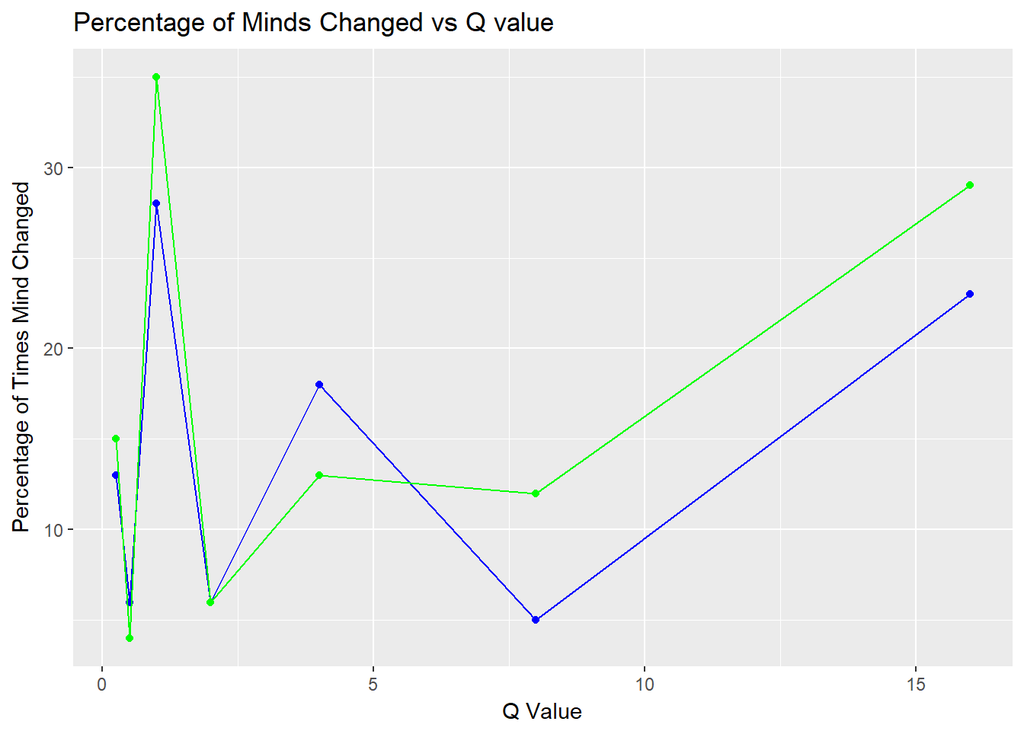

```r
load("testing_Q.Rda")
ggplot(df, aes(Q_val)) +
  geom_line(aes(y=pilot_c1), colour="blue") + geom_point(aes(y=pilot_c1), colour="blue")  +
  geom_line(aes(y=pilot_c2), colour="green") + geom_point(aes(y=pilot_c2), colour="green") +
  ylab("Percentage of Times Mind Changed") + xlab("Q Value") +
  labs(title="Percentage of Minds Changed vs Q value")
```

Here, we’ve again run a case where there are only two cities to chose from, we can run a pilot in only one city, and we can run the final program in only one city. City 1 has an initial prior $Y_1 \sim (1,1)$ and city 2 has an initial prior $Y_2 \sim (0,1)$ where $x$. What changes here is the variance of the pilot, where the pilot variance is Q times ‘better’ than the original study (A Q value of 5 corresponds with a pilot that has a fifth of the variance, a Q value of 1/2 means the pilot has twice the variance of the original study). Each simulation has been run 100 times, and the number of times changing the initial ranking (deciding to go for city 2 rather than city 1) has been plotted as the percentage of times we changed our minds (y). Piloting city 1 results plotted in blue, piloting city 2 results plotted in green.

```r
Q_val <- c(0.25,0.5,1,2,4,8,16)
Q <- length(Q_val)
N <- 11
pilot_c1 <- matrix(nrow = N, ncol = Q)
pilot_c2 <- matrix(nrow = N, ncol = Q)
sample <- seq(0,1,length.out = N)
```

```r
for (n in 1:N){
  for (q in 1:Q){
    data <- list(I=2,Y=c(sample[n],0),sigmaSq=c(1,1))
    results <- overall(data=data,num_pilots=1,num_final_cities=1,num_draws=10,Q=Q_val[q])
    pilot_c1[n,q] <- results$nmc[1]
    pilot_c2[n,q] <- results$nmc[2]
  }
}

df <- data.frame(pilot_c1, pilot_c2)
save(df, file="testing_Q_and_mean.Rda")
save(pilot_c1, file = "Q_and_mean_c1.Rdata")
save(pilot_c2, file = "Q_and_mean_c2.Rdata")
```

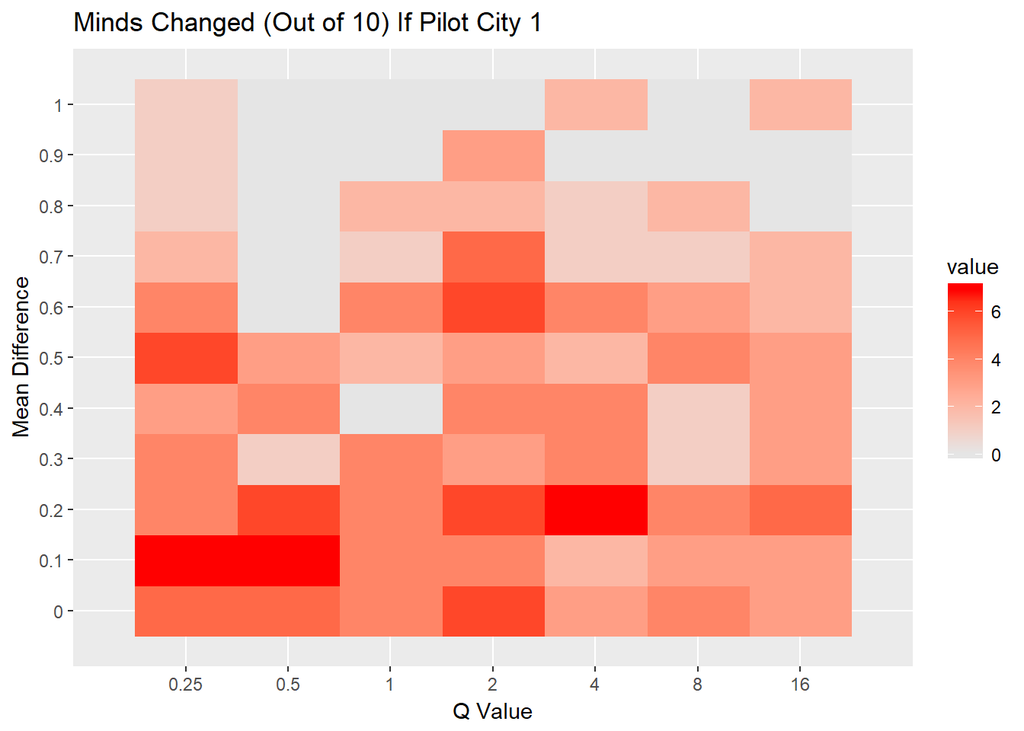

```r
load("Q_and_mean_c1.Rdata")
longData<-melt(pilot_c1)

ggplot(longData, aes(x = Var2, y = Var1)) +
  geom_raster(aes(fill=value)) +
  scale_fill_gradient(low="grey90", high="red") +
  labs(x="Q Value", y="Mean Difference", title="Minds Changed (Out of 10) If Pilot City 1") +
  scale_x_discrete(name ="Q Value", limits=as.character(Q_val)) +
  scale_y_discrete(name ="Mean Difference", limits=as.character(sample))
```

Here we’re trying to visualize how changing both the difference between the means of the two cities and the variance of the pilot studies (described by Q, with Q=3 implying the pilot variance is 1/3 of the original study variance). City 1 has prior mean x ranging fro 0 to 1 while city 2 has prior mean 0; both have prior variance 1. Here we can see that as the cities have closer means and the variance of the pilot study becomes larger, we’re more likely to change our minds, as one would expect. Each square in this matrix represents the results of running the same simulation 10 times, counting the total number of times out of 10 that our mind is changed away from choosing city 1 as the final program destination, given that we choose to implement the pilot in city 1.

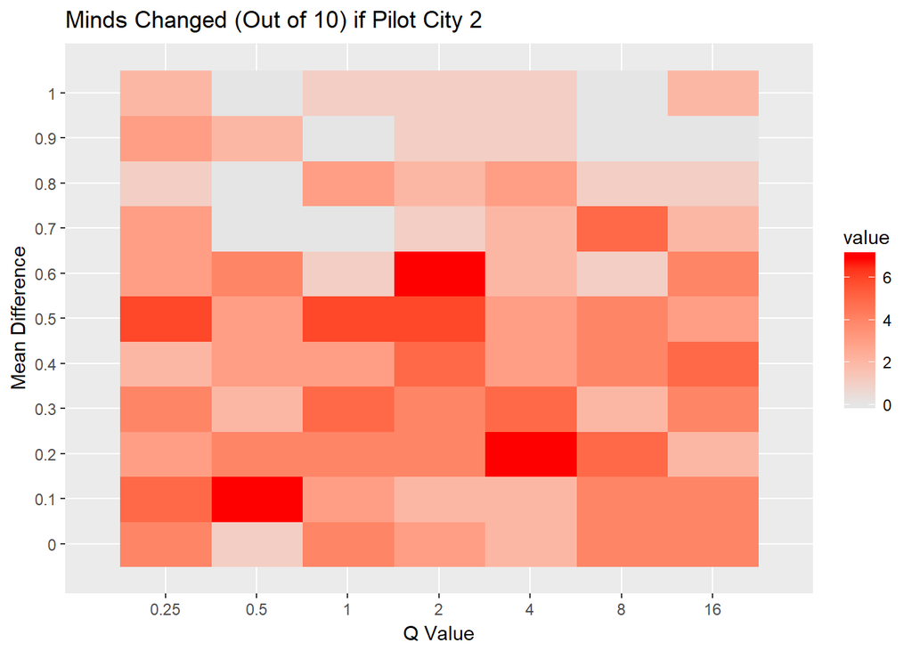

```r
load("Q_and_mean_c2.Rdata")
longData<-melt(pilot_c2)

ggplot(longData, aes(x = Var2, y = Var1)) +
  geom_raster(aes(fill=value)) +
  scale_fill_gradient(low="grey90", high="red") +
  labs(x="Q Value", y="Mean Difference", title="Minds Changed (Out of 10) if Pilot City 2") +
  scale_x_discrete(name ="Q Value", limits=as.character(Q_val)) +
  scale_y_discrete(name ="Mean Difference", limits=as.character(sample))
```

Here we’re trying to visualize how changing both the difference between the means of the two cities and the variance of the pilot studies (described by Q, with Q=3 implying the pilot variance is 1/3 of the original study variance). City 1 has prior mean x ranging fro 0 to 1 while city 2 has prior mean 0; both have prior variance 1. Here we can see that as the cities have closer means and the variance of the pilot study becomes larger, we’re more likely to change our minds, as one would expect. Each square in this matrix represents the results of running the same simulation 10 times, counting the total number of times out of 10 that our mind is changed away from choosing city 1 as the final program destination, given that we choose to implement the pilot in city 2.

```r
J <- 10 # Number of times we retry per tau
N <- 11 # Number of different tau values
pilot_c1 <- matrix(nrow = N, ncol = J)
pilot_c2 <- matrix(nrow = N, ncol = J)
sample <- seq(0,2,length.out = N)
```

```r
for (n in 1:N){
  for (j in 1:J){
    data <-generate_basic(I=2,mu=0,tau=sample[n],SF=1)
    results <- overall(data=data,num_pilots=1,num_final_cities=1,num_draws=10)
    pilot_c1[n,j] <- results$nmc[1]
    pilot_c2[n,j] <- results$nmc[2]
  }
}

save(pilot_c1, file = "tau_c1.Rdata")
save(pilot_c2, file = "tau_c2.Rdata")
```

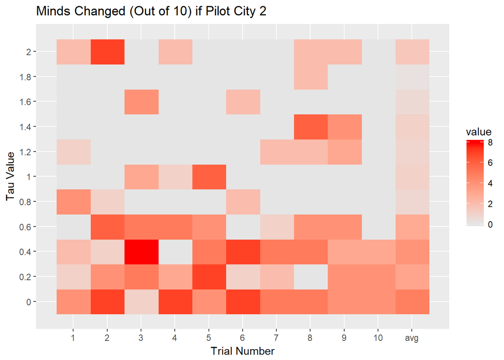

```r
load("tau_c1.Rdata")
with_avg <- cbind(pilot_c1,rowMeans(pilot_c1))
longData<-melt(with_avg)

ggplot(longData, aes(x = Var2, y = Var1)) +
  geom_raster(aes(fill=value)) +
  scale_fill_gradient(low="grey90", high="red") +
  labs(title="Minds Changed (Out of 10) if Pilot City 2") +
  scale_x_discrete(name ="Trial Number", limits=c(as.character(seq(1,J)),"avg")) +
  scale_y_discrete(name ="Tau Value", limits=as.character(sample))
```

Here we’re looking at the effect of changing tau on the number of minds changed. Tau has been tested in the range of 0-2. For each tau value, we generate 10 different initial data trials, and for each of those trials, run 10 pilot simlations. The average result of each of the 10 tau trials is captured in the rightmost column. The scenario here deals with 2 possible cities, one pilot city, and one city to choose as the final city. Here we plot the number of times we change our minds (out of 10 possible opportunities) if we pilot city 1. We’d expect the plot for the times we pilot city 2(below) to be comparable, in that city 1 and city 2 are generated from the same distribution N(mu=0, tau2).

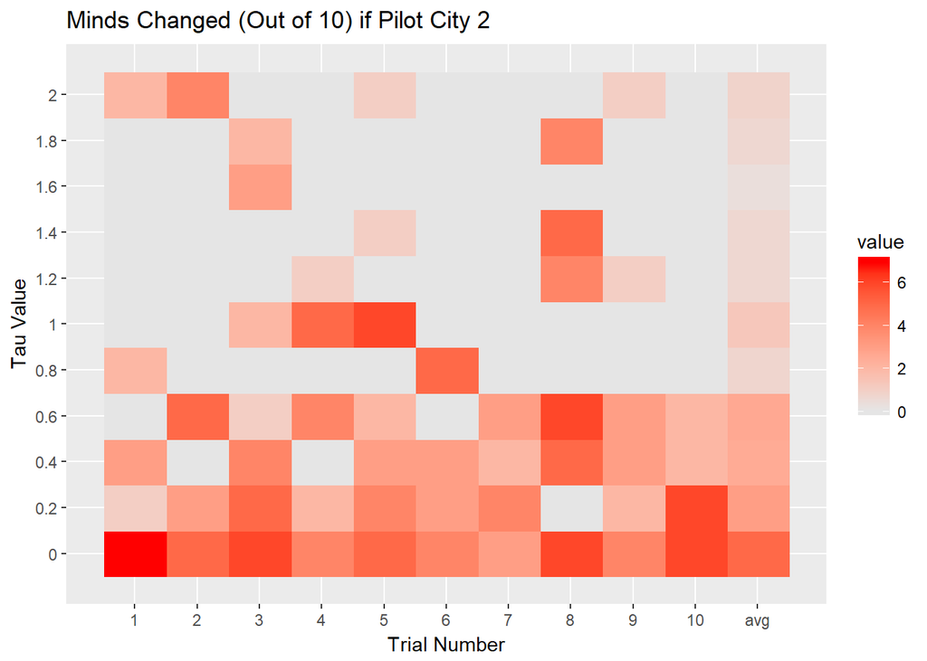

```r
load("tau_c2.Rdata")
with_avg <- cbind(pilot_c2,rowMeans(pilot_c2))
longData<-melt(with_avg)

ggplot(longData, aes(x = Var2, y = Var1)) +
  geom_raster(aes(fill=value)) +
  scale_fill_gradient(low="grey90", high="red") +
  labs(title="Minds Changed (Out of 10) if Pilot City 2") +
  scale_x_discrete(name ="Trial Number", limits=c(as.character(seq(1,J)),"avg")) +
  scale_y_discrete(name ="Tau Value", limits=as.character(sample))
```